# Analysis and Interpretation of Results

Pierce County Project

Edberto, Gerta, Helga, & Mira

2026-05-11

## Data

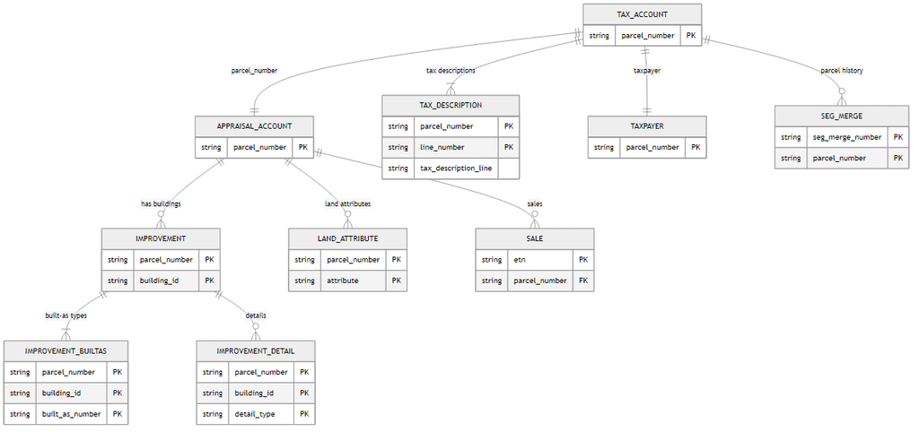

ER Diagram

## Data Cleaning

- columns with over 80% missing values were removed
- highly correlated columns were removed
- data tables were joined
- irrelevant columns (identifiers, one unique value, unique strings) were removed

At the end 63 candidate variables remained.

## EDA

### Focus: Sales Price (target variable)

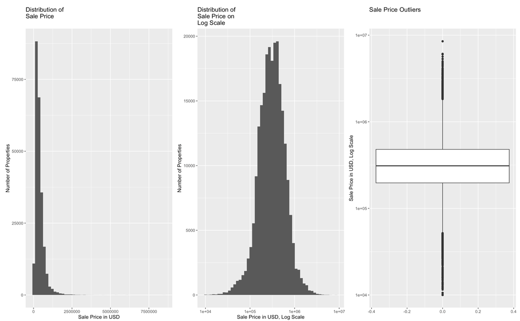

Distribution of sale price

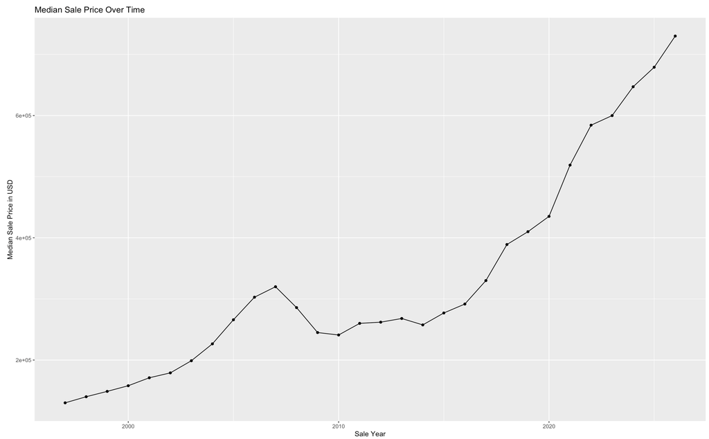

Median Sale Prices over Time

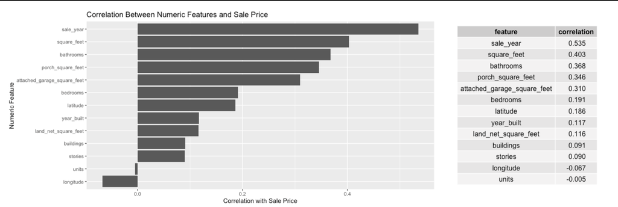

Correlation between numeric features and sale price

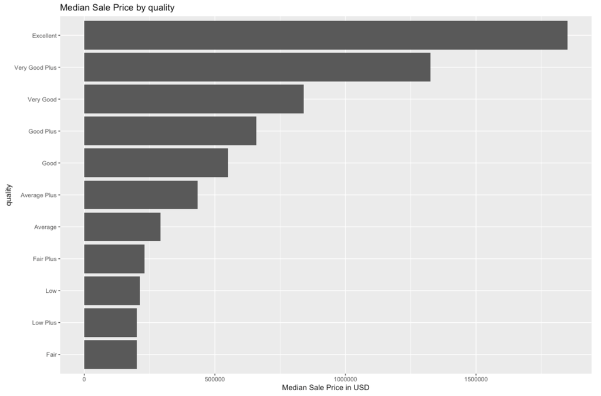

Median price for each quality level

### Selected Variables and Interactions

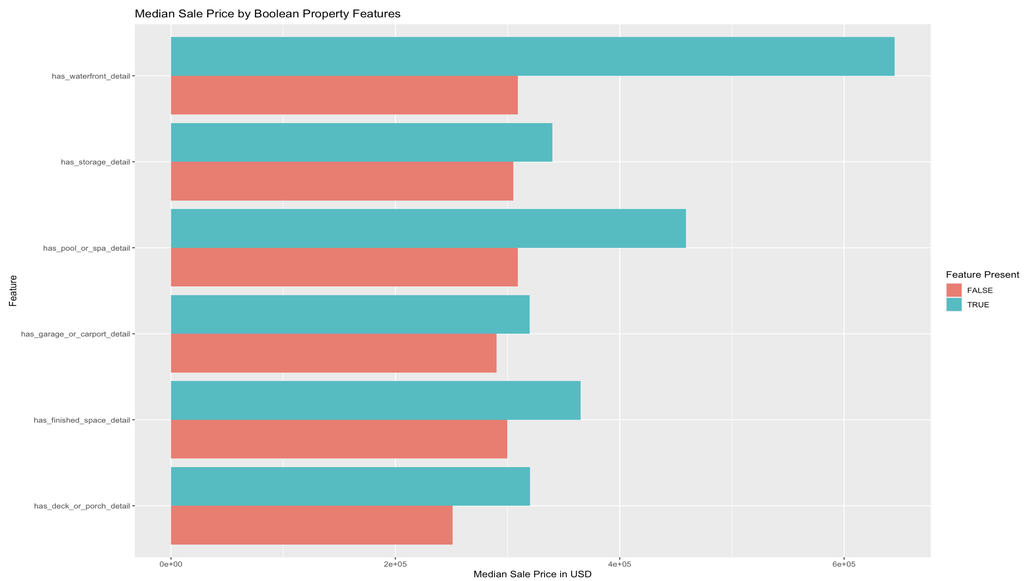

Price when selected features are available vs not

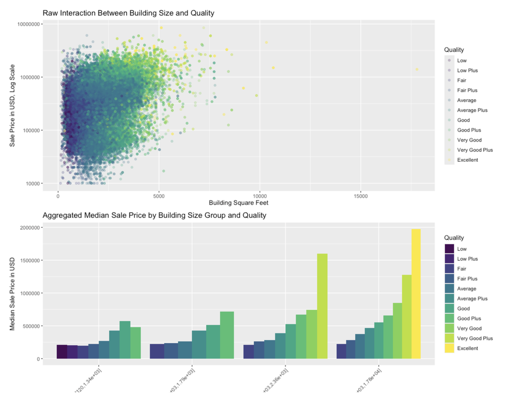

Interaction between building size and quality

### Constructed Variables

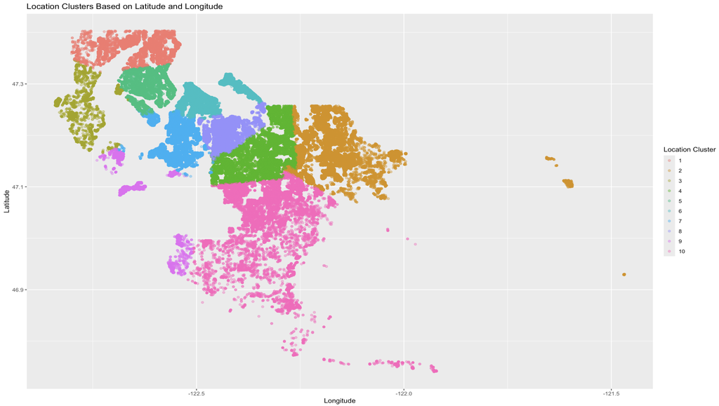

Location clustering

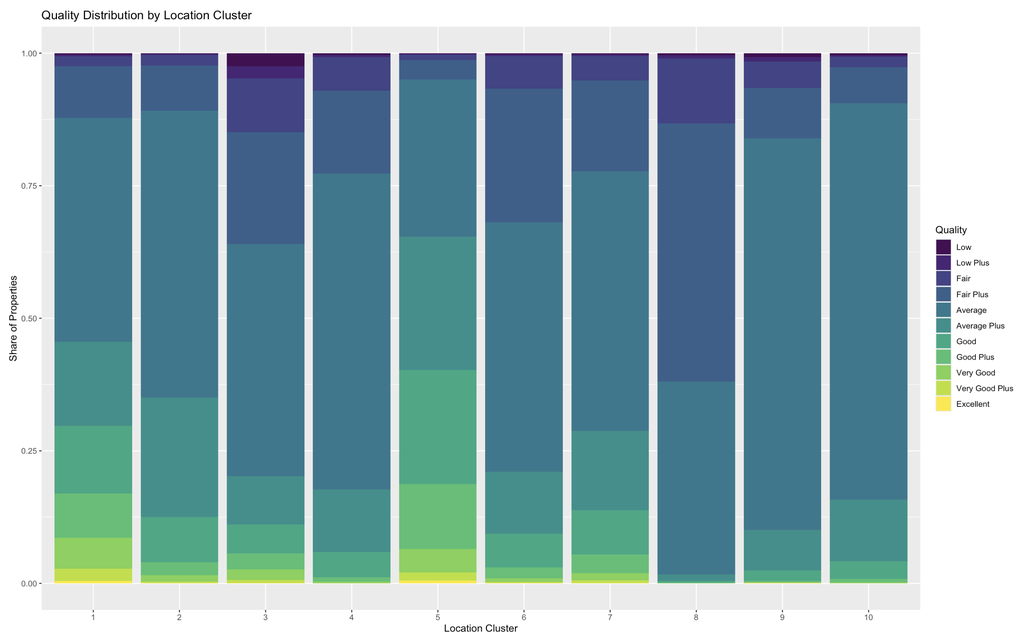

Quality levels by location cluster

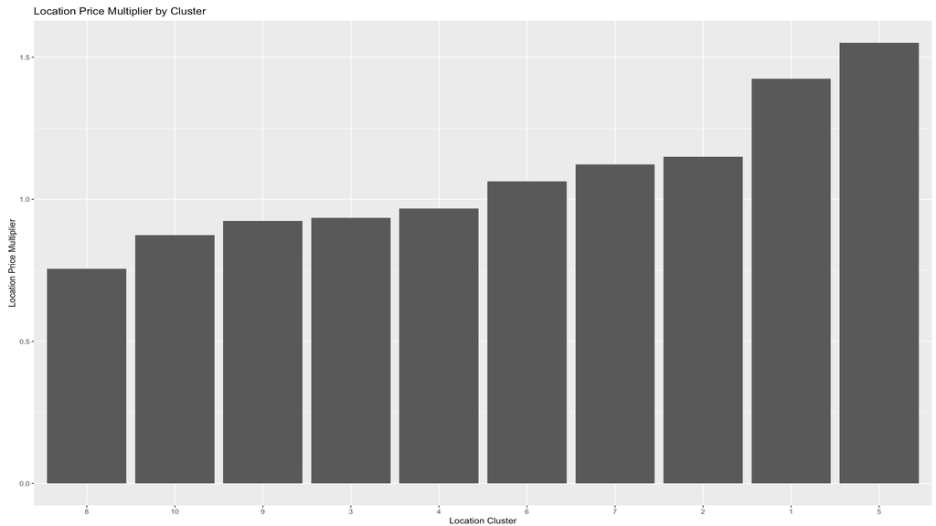

Location multiplier (median of cluster/global median)

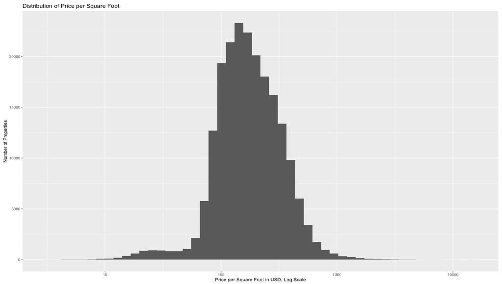

Distribution of squarefoot price

## Final Variable Selection

| App input | Used to create model features |
| --- | --- |
| Address or map location | `latitude`, `longitude`, `location_cluster` - will be derived |
| Sale year | `sale_year` |
| Living area | `square_feet` |
| Land size | `land_net_square_feet` |
| Porch/deck yes/no | `has_deck_or_porch_detail` |
| Porch/deck size | `porch_square_feet` |
| Garage yes/no | `has_garage_or_carport_detail` |
| Garage size | `attached_garage_square_feet` |
| Quality rating | `quality_score` |
| Number of bedrooms | `bedrooms`, `bedrooms_per_1000_sqft` - will be derived |
| Number of bathrooms | `bathrooms`, `bathrooms_per_1000_sqft` - will be derived |
| Year built | `year_built` |
| Pool/spa yes/no | `has_pool_or_spa_detail` |
| Waterfront yes/no | `has_waterfront_detail` |
| Finished extra space yes/no | `has_finished_space_detail` |

## Competing models

1. Base Models
2. Linear Regression
3. KNN
4. LightGBM

## Base Model

The Baseline 1 model predicts the mean log sale price for all properties. Its performance is extremely poor. The RMSE of **315,683 USD** and MAE of **185,274 USD** indicate that the model cannot capture any meaningful variation in sale prices. The MAPE of 64.25% and the fact that only 17.86% of predictions fall within 15% of the true price further confirm that the naïve mean predictor is inadequate. This baseline serves as a lower bound for model performance: any useful predictive model must substantially outperform this benchmark.

The simple **linear regression** baseline performs substantially better than the naïve mean model, reducing RMSE from **315k USD to 226k USD** and increasing R² to 0.465. However, the model still leaves more than half of the variance unexplained and produces a MAPE of 33%, indicating that linear effects alone are insufficient to model residential sale prices. This confirms that house prices exhibit strong nonlinear and interaction effects, which require more flexible models such as gradient boosting.

| Model | RMSE | MAE | R_squared | MAPE |
| --- | --- | --- | --- | --- |
| Mean Model | 315682.7 | 185274.24 | NA | 64.25098 |
| Linear Regression | 225930.5 | 108037.99 | 0.4654660 | 33.11315 |
| Ridge Regression | 203716.4 | 101554.28 | 0.6456080 | 33.25099 |
| LASSO Regression | 183186.9 | 91825.22 | 0.6843780 | 30.28490 |
| Elastic Net Regression | 188257.1 | 93482.68 | 0.6780421 | 30.58247 |

## Linear Regression

Key features include:

- **Physical Characteristics**: `square_feet`, `bedrooms`, `bathrooms`, `year_built`.
- **Quality Indicators**: `quality_score`, `total_size_score`.
- **Location**: `latitude`, `longitude`.
- **Interactions**: `square_feet_quality_interaction`, `waterfront_land_interaction`.

## Step 3: Performance Evaluation

The model performance is assessed using R-squared and error metrics.

```
R-squared: 0.5804
```

```
Adjusted R-squared: 0.5803
```

```
AIC: 5562587
```

The $R^2$ value indicates that approximately 58% of the variation in sale prices is explained by the selected features.

## Step 4: Interpretation of Coefficients

The coefficients reveal the impact of each unit change in the predictors on the home price.

Model Coefficients and Significance

| term | estimate | std.error | statistic | p.value |
| --- | --- | --- | --- | --- |
| sale_year | 18809.7777 | 49.1021 | 383.0746 | 0 |
| square_feet_quality_interaction | 27.2909 | 0.3168 | 86.1566 | 0 |
| latitude | 348837.4553 | 5708.9935 | 61.1031 | 0 |
| land_net_square_feet | 0.3916 | 0.0079 | 49.6340 | 0 |
| quality_score | 39497.5500 | 873.3295 | 45.2264 | 0 |
| square_feet | -89.2824 | 2.1612 | -41.3121 | 0 |
| year_built | -495.4429 | 16.1048 | -30.7637 | 0 |
| bedrooms | -8282.3164 | 615.4504 | -13.4573 | 0 |
| bathrooms | 329.4927 | 67.5683 | 4.8764 | 0 |
| longitude | 13494.4742 | 3115.8890 | 4.3309 | 0 |

## Step 5: Validation of Assumptions

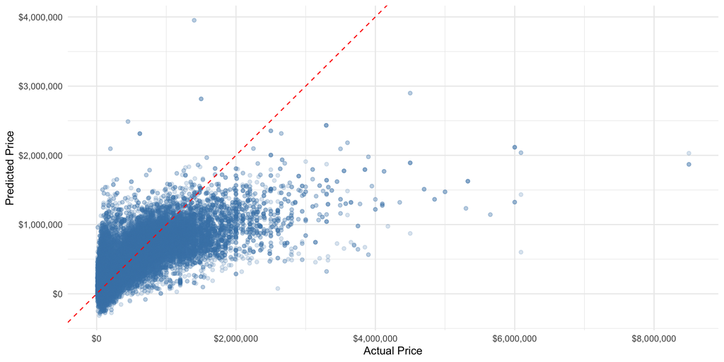

Actual vs. Predicted Prices

# Conclusion

This model is exported as `linear_regression_model.rds` and serves as the core predictive engine for the **House Price Prediction Shiny App**, enabling real-time estimates based on user-provided property characteristics.

## KNN

| Model | k | RMSE | R-squared | MAE |
| --- | --- | --- | --- | --- |
| **minimal** | 5 | 238751.3803545 | 0.3306106 | 147812.9377174 |
| **+sale_year** | 5 | 144276.2798941 | 0.7555574 | 68750.728318 |
| **+sale_year+quality** | 5 | 131114.1538997 | 0.7981233 | 62419.957656 |
| **full** | 5 | 135948.394173 | 0.7829623 | 63882.6578432 |

| Model | within 15% train | within 15% test |
| --- | --- | --- |
| **minimal** | 31.8473672 | 26.414956 |
| **+sale_year** | 69.2455723 | 62.4633431 |
| **+sale_year+quality** | 72.6508519 | 65.4692082 |
| **full** | 72.140732 | 65.4032258 |

## LightGBM

Two LightGBM feature-reduction models were compared to decide which model is more suitable for the final app.

| Model | Removed features | RMSE | MAE | R-squared | MAPE | Within 15% |
| --- | --- | --- | --- | --- | --- | --- |
| Model that eliminates 3 features | `bedrooms`, `has_finished_space_detail`, `has_garage_or_carport_detail` | 88,896.91 | 41,668.10 | 0.9095 | 12.53% | 76.86% |
| Model that eliminates 7 features | `bedrooms_per_1000_sqft`, `bathrooms_per_1000_sqft`, `has_waterfront_detail`, `location_cluster`, `bedrooms`, `has_finished_space_detail`, `has_garage_or_carport_detail` | 90,574.49 | 42,210.63 | 0.9058 | 12.63% | 76.38% |
| Differences between models | Model with 7 removed features minus model with 3 removed features | +1,677.58 | +542.53 | -0.0037 | +0.10 % | -0.48 % |

The model that eliminates 7 features has slightly weaker performance than the model that eliminates 3 features, but the difference is small. RMSE increases by 1,677.58 USD, MAE increases by 542.53 USD, MAPE increases by only 0.10 percentage points, and the percentage of predictions within 15 percent decreases by only 0.48 percentage points.

Because the model that eliminates 7 features removes 4 additional input variables while keeping very similar performance, it may be more suitable for the final app from a usability perspective.

It suggests excluding `bedrooms_per_1000_sqft`, `bathrooms_per_1000_sqft`, `has_waterfront_detail`, `location_cluster`, `bedrooms`, `has_finished_space_detail`, and `has_garage_or_carport_detail`.